# Computer Assignment 2: France (Group 12)

Javier Torralba Flores (ANR u146430, SNR 2042878)

Maximilian Grotz (ANR u271366, SNR 2056313)

Abdirahman Nuur (ANR u824009 , SNR 2057152)

Mathieu Van de Vel (ANR u130770, SNR 2050053)

01/05/2021

# Q1: Data preperation

We will be using the GDP and investment data in euro, as this was the best data we found and transforming it using the exchange rate would lead to high fluctuation.

All working files can be found on [GitHub](https://github.com/max1m1l1anG/Macro2_CompAsignment2_France).

```r
# Here we import all relevant packages and set options

library(dplyr)
library(tidyverse)
library(lubridate) # This package is used for working with dates
library(knitr) # This package is for nice tables
library(kableExtra) # Package for even nicer tables.

options(scipen = 999) # Disable scientific notation
```

```r
# Importing the Current Account Balance as a % of GDP of France
# SOURCE: FRED https://fred.stlouisfed.org/series/FRAB6BLTT02STSAQ

CABalance_FR <- read_csv("sourcecode/FRED_bop_france_quarterly.csv",
    col_types = cols(DATE = col_date(format = "%d/%m/%Y"),
        FRAB6BLTT02STSAQ = col_number())) %>%
  mutate(FRAB6BLTT02STSAQ = FRAB6BLTT02STSAQ /100) %>%
  rename(date = DATE, CAasPercGDP_quart_FR = FRAB6BLTT02STSAQ)


# Importing the General Government Debt as a % of GDP.
# THIS IS NOT IN PERCENT! GOVERNMENT DEBT OF 100%  => 1
# SOURCE: OECD https://data.oecd.org/gga/general-government-debt.htm

GovDebt_FR <- read_csv("sourcecode/OECD_gov_debt_annual.csv",
    col_types = cols(LOCATION = col_character(),
        INDICATOR = col_skip(), SUBJECT = col_skip(),
        MEASURE = col_skip(), FREQUENCY = col_skip(),
        TIME = col_date(format = "%Y"), Value = col_number(),
        `Flag Codes` = col_skip())) %>%
  rename(date = TIME) %>%
  filter(LOCATION == "FRA") %>%
  mutate(LOCATION = NULL, GovDebt_ann_FR = Value / 100, Value = NULL)


# This function transform dates in a quarterly format of "2000-Q1" to 2000-01-01
QuarterToDate <- function(QuarterlyDate){

  NumberofQuarter <- substr(QuarterlyDate, 7, 7)

  Month <- 3 * as.numeric(NumberofQuarter) - 2
  Month <- ifelse(Month == 10, Month, paste(0, Month))

  Year <- substr(QuarterlyDate, 1, 4)

  Date_String <- paste(Year, "-", Month, "-01") %>%
    str_replace_all(" ", "")

  Date <- as.Date(Date_String)

  Date
}

# Importing Interest Rate on Government Bonds (10 year),
# also called "Long term interest rate", in %/annum
# SOURCE: OECD https://data.oecd.org/interest/long-term-interest-rates.htm

IntRate_FR <- read_csv("sourcecode/OECD_interest_rates_france_quarterly.csv",
    col_types = cols(INDICATOR = col_skip(),
        SUBJECT = col_skip(), MEASURE = col_skip(),
        FREQUENCY = col_skip(), Value = col_number(),
        `Flag Codes` = col_skip())) %>%
  mutate(date = QuarterToDate(TIME),
         IntRate_quart_FR = Value / 100,
         Value = NULL, TIME = NULL, LOCATION = NULL)


# Exchange rate against the US dollar
# SOURCE: FRED https://fred.stlouisfed.org/series/DEXUSEU

XR_EurUSD <- read_csv("sourcecode/FRED_exchage_rate_quarterly.csv",
    col_types = cols(DATE = col_date(format = "%d/%m/%Y"),
        DEXUSEU = col_number())) %>%
  rename(date = DATE, XR_quart_EurUSD = DEXUSEU) %>%
  mutate(XR_quart_EurUSD = 1/XR_quart_EurUSD)


# Total GDP, in millions of US dollars
# SOURCE: FRED https://fred.stlouisfed.org/series/CPMNACSCAB1GQFR

GDP_FR <- read_csv("sourcecode/FRED_euros_france_gdp_quarterly.csv",
    col_types = cols(DATE = col_date(format = "%d/%m/%Y"),
        CPMNACSCAB1GQFR = col_number())) %>%
  mutate(date = DATE, GDP_quart_Millionseur_FR = CPMNACSCAB1GQFR,
         CPMNACSCAB1GQFR = NULL, DATE = NULL)


# Investment (usually Gross Fixed Capital Formation), in millions of US dollars
# SOURCE: FRED https://fred.stlouisfed.org/series/FRAGFCFQDSMEI#0

Invest_FR <- read_csv("sourcecode/FRED_euros_investments_quarterly.csv",
    col_types = cols(DATE = col_date(format = "%d/%m/%Y"),
        FRAGFCFQDSMEI = col_number())) %>%
  mutate(Invest_quart_Millionseur_FR = FRAGFCFQDSMEI / 1000000,
         FRAGFCFQDSMEI = NULL) %>%
  rename(date = DATE)


# Gross national savings as a % of GDP (savings rate).
# Again, this is in decimals, and not percent!
# SORUCE: World Bank https://data.worldbank.org/indicator/NY.GNS.ICTR.ZS

SavingsR_FR <- read_csv("sourcecode/WorldBank_GrossSavings_annual.csv",
    col_types = cols(`Country Code` = col_skip(),
        `Indicator Name` = col_character(),
        `Indicator Code` = col_skip()), skip = 3) %>%
  filter(`Country Name` == "France") %>%
  pivot_longer(cols = -c(`Country Name`, `Indicator Name`),
               names_to = "date",
               values_to = "Savings_PercentageGDP") %>%
  mutate(`Country Name` = NULL,
         `Indicator Name` = NULL,
         date = as.Date(paste(date, "-01-01", sep = "")),
         SavR_ann_FR = Savings_PercentageGDP / 100,
         Savings_PercentageGDP = NULL) %>%
  filter(date >= "1999-01-01", "2019-01-01" >= date)
# Merging them all together

DF_FR <- CABalance_FR %>%
  full_join(IntRate_FR, by = "date") %>%
  full_join(XR_EurUSD, by = "date") %>%
  full_join(GDP_FR, by = "date") %>%
  full_join(Invest_FR, by = "date") %>%
  full_join(GovDebt_FR, by = "date") %>%
  full_join(SavingsR_FR, by = "date") %>%
  filter(date != "1998-10-01") %>%
  mutate(InvestmentR_Fr = Invest_quart_Millionseur_FR/GDP_quart_Millionseur_FR)


# Creating and printing a table with all the quarterly data

DF_quart_FR <- DF_FR %>%
  select(!c(GovDebt_ann_FR, SavR_ann_FR)) %>%
  mutate(date = format(as.Date(date), "%Y-%m"),
         InvestmentR_Fr = InvestmentR_Fr * 100) %>%
  rename(`Current Account Balance as % of GDP` = CAasPercGDP_quart_FR,
          `Inflation Rate` = IntRate_quart_FR,
          `Exchange Rate €/USD` = XR_quart_EurUSD,
          `GDP in millions of €` = GDP_quart_Millionseur_FR,
          `Invesment in millions of €` = Invest_quart_Millionseur_FR,
          `Investment rate as % of GDP` = InvestmentR_Fr,
         `Date (Year-Month)` = date
          )

table_quart_FR <- DF_quart_FR %>%
  kable(caption = "Quarterly data for France") %>%
  kable_classic(html_font = "Cambria", full_width = TRUE, font_size = 7.5)
```

Quarterly data for France

| Date (Year-Month) | Current Account Balance as % of GDP | Inflation Rate | Exchange Rate €/USD | GDP in millions of € | Invesment in millions of € | Investment rate as % of GDP |
| --- | --- | --- | --- | --- | --- | --- |
| 1999-01 | 0.0438439 | 0.0394417 | 0.8925227 | 344117 | 70478 | 20.48082 |
| 1999-04 | 0.0484796 | 0.0420357 | 0.9463116 | 347464 | 72075 | 20.74316 |
| 1999-07 | 0.0222956 | 0.0500457 | 0.9530362 | 351727 | 73845 | 20.99498 |
| 1999-10 | 0.0221505 | 0.0528283 | 0.9644766 | 356592 | 74774 | 20.96906 |
| 2000-01 | 0.0158500 | 0.0557097 | 1.0143425 | 362660 | 76970 | 21.22374 |
| 2000-04 | 0.0193270 | 0.0538640 | 1.0713144 | 367789 | 78600 | 21.37095 |
| 2000-07 | 0.0031609 | 0.0539280 | 1.1059345 | 372166 | 80714 | 21.68763 |
| 2000-10 | 0.0059001 | 0.0522770 | 1.1518233 | 376980 | 82060 | 21.76773 |
| 2001-01 | 0.0177723 | 0.0490307 | 1.0846480 | 380845 | 82467 | 21.65369 |
| 2001-04 | 0.0121254 | 0.0511897 | 1.1446579 | 383539 | 82632 | 21.54461 |
| 2001-07 | 0.0138967 | 0.0501560 | 1.1226068 | 386507 | 83310 | 21.55459 |
| 2001-10 | 0.0191345 | 0.0472020 | 1.1171453 | 388555 | 82894 | 21.33392 |
| 2002-01 | 0.0149088 | 0.0505460 | 1.1402082 | 392514 | 82625 | 21.05020 |
| 2002-04 | 0.0119863 | 0.0520337 | 1.0886631 | 395640 | 82682 | 20.89829 |
| 2002-07 | 0.0081239 | 0.0469693 | 1.0160746 | 399012 | 83542 | 20.93721 |
| 2002-10 | 0.0109505 | 0.0448997 | 0.9997210 | 401288 | 84117 | 20.96175 |
| 2003-01 | 0.0090230 | 0.0411140 | 0.9316889 | 403234 | 84730 | 21.01261 |
| 2003-04 | 0.0038581 | 0.0393603 | 0.8805736 | 404603 | 85027 | 21.01492 |
| 2003-07 | 0.0076567 | 0.0413373 | 0.8877829 | 409627 | 86474 | 21.11042 |
| 2003-10 | 0.0127764 | 0.0434240 | 0.8389228 | 414298 | 87009 | 21.00155 |
| 2004-01 | 0.0118070 | 0.0410590 | 0.8000692 | 419847 | 88890 | 21.17200 |
| 2004-04 | 0.0047740 | 0.0430660 | 0.8301123 | 423647 | 90435 | 21.34678 |
| 2004-07 | 0.0035573 | 0.0415890 | 0.8178893 | 426215 | 91196 | 21.39671 |
| 2004-10 | 0.0013484 | 0.0382527 | 0.7697562 | 431768 | 92734 | 21.47774 |
| 2005-01 | 0.0027883 | 0.0364193 | 0.7626489 | 435001 | 93764 | 21.55489 |
| 2005-04 | -0.0013907 | 0.0337377 | 0.7941875 | 438435 | 95310 | 21.73868 |
| 2005-07 | 0.0034557 | 0.0323350 | 0.8199746 | 441972 | 96752 | 21.89098 |
| 2005-10 | -0.0006566 | 0.0338857 | 0.8410278 | 448518 | 98537 | 21.96946 |
| 2006-01 | 0.0014081 | 0.0351250 | 0.8310780 | 453785 | 100428 | 22.13119 |
| 2006-04 | -0.0031370 | 0.0398703 | 0.7951476 | 460637 | 103263 | 22.41744 |

[output cut: 58 more lines]

```r
# Creating and printing a table with all the annual data

DF_ann_FR <- DF_FR %>%
  select(c(date, GovDebt_ann_FR, SavR_ann_FR)) %>%
  mutate(date = format(as.Date(date), "%Y"),
         GovDebt_ann_FR = GovDebt_ann_FR * 100,
         SavR_ann_FR = SavR_ann_FR * 100) %>%
  na.omit() %>%
  rename(`General government debt as a % of GDP` = GovDebt_ann_FR,
         `Gross national savings as a % of GDP` = SavR_ann_FR,
         `Year` = date)

DF_ann_FR %>%
  kable(caption = "Annual data for France") %>%
  kable_classic(html_font = "Cambria", full_width = TRUE)
```

Annual data for France

| Year | General government debt as a % of GDP | Gross national savings as a % of GDP |
| --- | --- | --- |
| 1999 | 74.01518 | 24.49345 |
| 2000 | 72.42918 | 23.83472 |
| 2001 | 71.47308 | 23.93909 |
| 2002 | 75.16156 | 22.74479 |
| 2003 | 79.07757 | 22.23459 |
| 2004 | 80.54945 | 22.54925 |
| 2005 | 82.14224 | 22.46340 |
| 2006 | 77.26933 | 23.30634 |
| 2007 | 75.94181 | 23.74657 |
| 2008 | 82.50349 | 23.43398 |
| 2009 | 97.57310 | 20.96452 |
| 2010 | 100.99530 | 21.08428 |
| 2011 | 103.80660 | 22.11296 |
| 2012 | 111.93820 | 21.45583 |
| 2013 | 112.46760 | 21.38918 |
| 2014 | 120.15510 | 21.48595 |
| 2015 | 120.82520 | 22.25404 |
| 2016 | 123.67070 | 22.00464 |
| 2017 | 122.94420 | 22.75294 |
| 2018 | 121.35990 | 23.05912 |
| 2019 | 123.96430 | 23.39520 |

# Q2: Government debt, interest rate, current account and the exchange rate

## 1. Government debt and interest rate

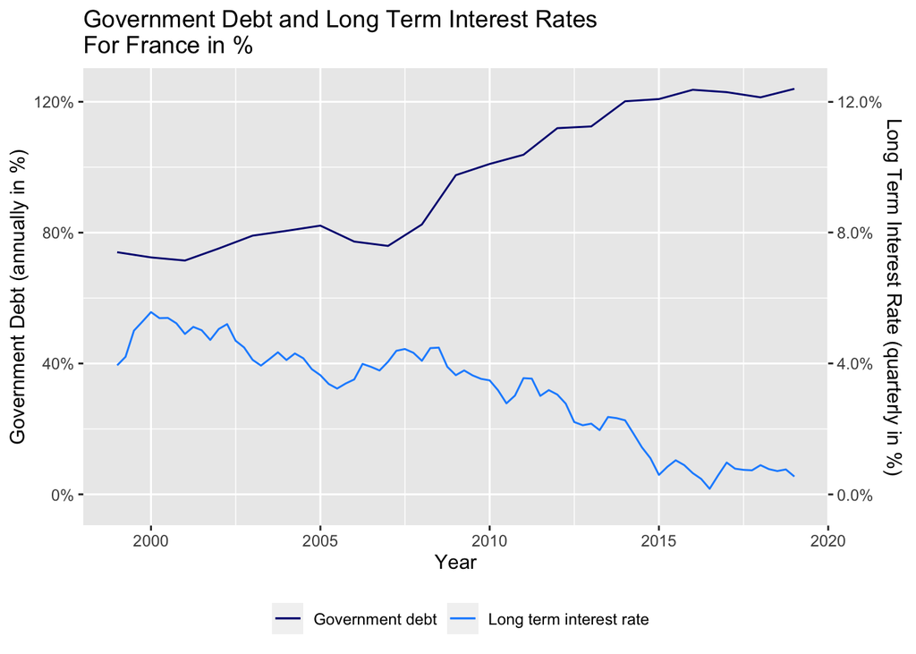

```r
#Creating plot for Gov Debt & Interest Rate v Time
#Omitting NA first
DF_FR_NA <- DF_FR %>%
  na.omit

#Assinging colors to titles
colors1 <- c("Government debt" = "navyblue",
             "Long term interest rate" = "dodgerblue1")

#Plotting graph
ggplot() +
  geom_line(DF_FR_NA,
            mapping = aes(x = date,
                          y = GovDebt_ann_FR,
                          color = "Government debt")) +
  geom_line(DF_FR,
            mapping = aes(x = date, y = IntRate_quart_FR*10,
                          color = "Long term interest rate")) +
  scale_y_continuous(labels = scales::percent,
                     name = "Government Debt (annually in %)",
                     sec.axis = sec_axis(~ . /10,
                                         name = "Long Term Interest Rate (quarterly in %)",
                                         labels = scales::percent)) +
  labs(x = "Year",
       title = "Government Debt and Long Term Interest Rates\nFor France in %",
       color = "") +
  scale_color_manual(values = colors1) +
  theme(legend.position="bottom") +
  scale_x_date(limits = c(as.Date("1999-01-01"), as.Date("2019-01-01")))
```

Government debt has been rising steadily, while long term interest rates have decreased. Hence, they move against each other. A cause might be that, during recessions, both low interest rates and increased government deficits are used as economic stimuli. Furthermore, low interest rates decrease the cost of borrowing for governments.

## 2. Current account and the exchange rate

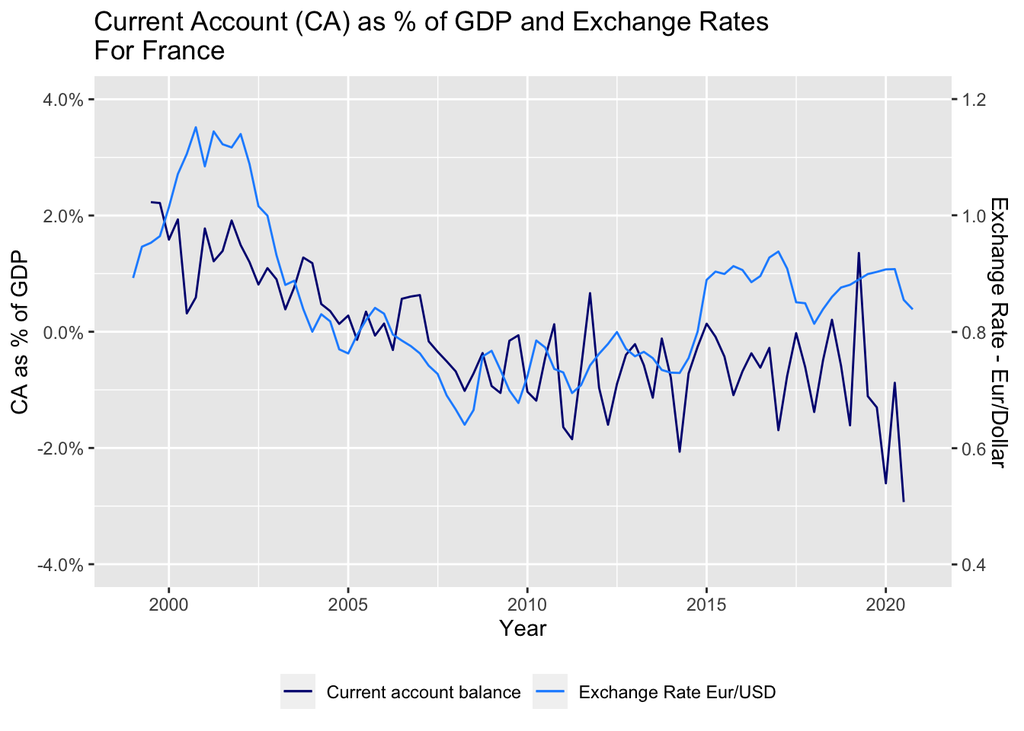

```r
#Assinging colors to titles
colors2 <- c("Current account balance" = "navyblue",
             "Exchange Rate Eur/USD" = "dodgerblue1")
#Plotting graph
ggplot() +
  geom_line(DF_FR,
            mapping = aes(x = date,
                          y = CAasPercGDP_quart_FR,
                          color = "Current account balance")) +
  geom_line(DF_FR,
            mapping = aes(x = date,
                          y = (XR_quart_EurUSD - 0.8) / 10,
                          color = "Exchange Rate Eur/USD")) +
  scale_y_continuous(labels = scales::percent,
                     limits = c(-.04, 0.04),
                     sec.axis = sec_axis(~ . *10 +.8,
                                         name = "Exchange Rate - Eur/Dollar")) +
  labs(x = "Year",
       y = "CA as % of GDP",
       title = "Current Account (CA) as % of GDP and Exchange Rates\nFor France",
       color = "") +
  scale_color_manual(values = colors2) +
  theme(legend.position="bottom")
```

The current account and the exchange rate have both decreased, seemingly almost moving together (deviations might occur because of e.g. changes in exchange rate expectations). Assuming relative price levels to be stable, if the euro appreciates, imports get more expensive, while exports become less competitive abroad, worsening the current account.

## 3. Relevant events and policy responses

The euro appreciated steadily in the early 2000s as it established itself as an international currency (Maggiori, Brent, & Schreger, 2019). This might, combined with France’s competitive weaknesses (International Monetary Fund. European Dept., 2013), have driven its deterioration of the current account. During the Great Recession government debt increased. Interest rates have declined due to a fall in both inflation expectations and the real interest rate (Claeys & Efstathiou, 2017). The latter and the sudden depreciation of the euro in 2015 were partly caused by the ECB’s quantitative easing program (Dedola, Georgiadis, Gräb, & Mehl, 2020).

## 4. Currency union and its effects

As France is a euro area country, it only has limited influence on its exchange rate and its monetary policy. To increase its real exchange rate it would need to decrease its price levels. France can reduce its current account deficit through contractionary fiscal policy, potentially disrupting its internal balance.

# Q3: Investment rate and the Feldstein-Horioka puzzle

## 1. Investment rate

## 2. Investment rate: Graph

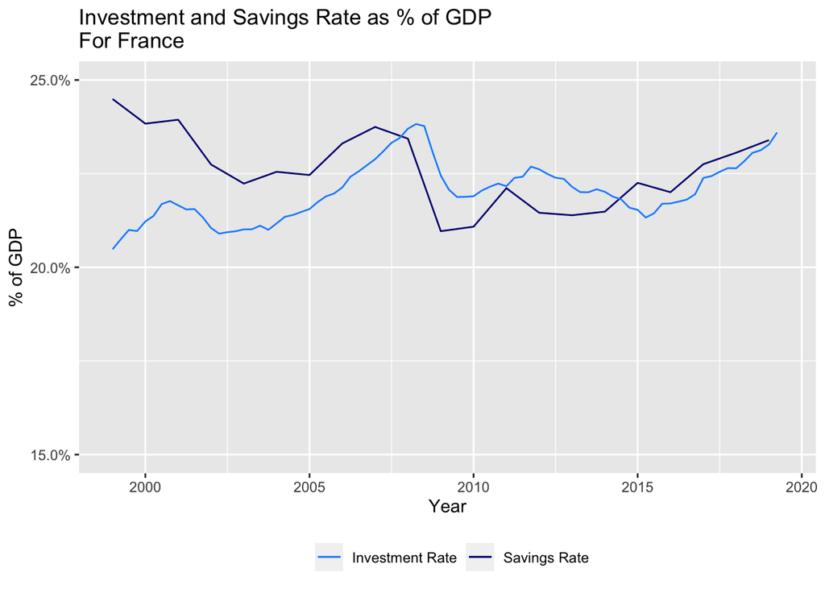

```r
#Assinging colors to titles
colors3 <- c("Savings Rate" = "navyblue", "Investment Rate" = "dodgerblue1")

#Plotting graph
ggplot() +
  geom_line(DF_FR_NA,
            mapping = aes(x = date,
                          y = SavR_ann_FR,
                          color = "Savings Rate")) +
  geom_line(DF_FR,
            mapping = aes(x = date,
                          y = InvestmentR_Fr,
                          color = "Investment Rate")) +
  labs(x = "Year",
       y = "% of GDP",
       title = "Investment and Savings Rate as % of GDP\nFor France",
       color = "") +
  scale_y_continuous(labels = scales::percent,
                     breaks = seq(0, 0.25, by = 0.05),
                     limits = c(0.15, 0.25)) +
  scale_color_manual(values = colors3) +
  theme(legend.position="bottom") +
  scale_x_date(limits = c(as.Date("1999-01-01"), as.Date("2019-06-01")))
```

## 3. Feldstein-Horioka puzzle

France’s investments and savings rates correlate quite strongly. According to Feldstein and Horioka this does not indicate a smoothly working international capital market. The graph illustrates an increasing correlation, more specifically, we see this correlation become stronger around the 2008 financial crisis, perhaps due to home bias on equity holdings.

# References

Claeys, G., & Efstathiou, K. (2017). Is the recent increase in long-term interest rates a threat to euro-area recovery? *Bruegel Policy Contribution* (2017/14). Retrieved from http://hdl.handle.net/10419/173110

Dedola, L., Georgiadis, G., Gräb, J., & Mehl, A. (2020, October 20). Does a big bazooka matter? Quantitative easing policies and exchange rates. *Research Bulletin*, 76. Retrieved from https://www.ecb.europa.eu/pub/economic-research/resbull/2020/html/ecb.rb201020~85fb68a983.en.html

International Monetary Fund. European Dept. (2013, August 5). France: Selected Issues paper. *IMF Staff Country Reports*, Volume 2013(Issue 252), 4-14. doi:https://doi.org/10.5089/9781484389133.002

Maggiori, M., Brent, N., & Schreger, J. (2019, May). The Rise of the Dollar and Fall of the Euro as International Currencies. *AEA Papers and Proceedings*, 109, 521-526. doi:10.1257/pandp.20191007